# EIS 2026 Information Sources

Where voters get election news, where they look for specific kinds of election information, and how both compare to 2024

Last updated September 19, 2026 at 6:37 PM

## Methodology

# How Often Voters Seek Election Information

BPC1 in the questionnaire - renamed to `seek_register`, `seek_elections_run`, and `seek_who_won`. Shown as the full weighted distribution across all five frequency categories, not collapsed to a single cutoff, since these categories are ordered (more/less often) but not evenly spaced. This is the item that defines “never-seekers” for Part 2 below: within each of the three information needs, a respondent who answers “Never” here is the one routed to that need’s hypothetical (“would you…”) arm instead of the actual one.

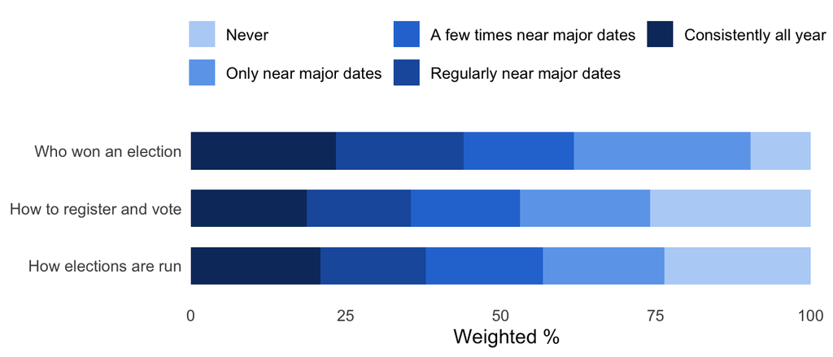

n = 3,144.

# Part 1: Where Voters Get Election News

## Main sources

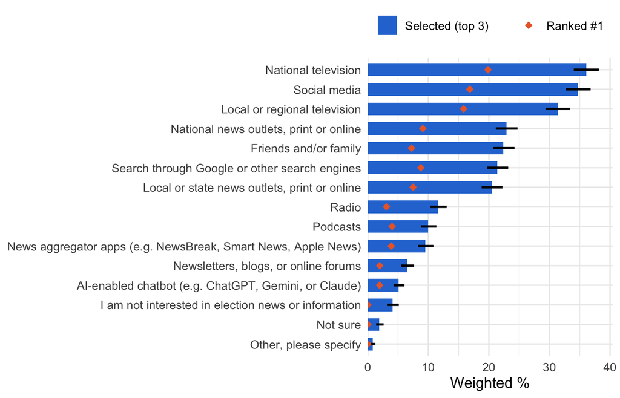

n = 3,144. Bars show the weighted % selecting each source among their top three; the diamond shows the weighted % who ranked that source their #1 choice.

## Drill-downs

### National television networks

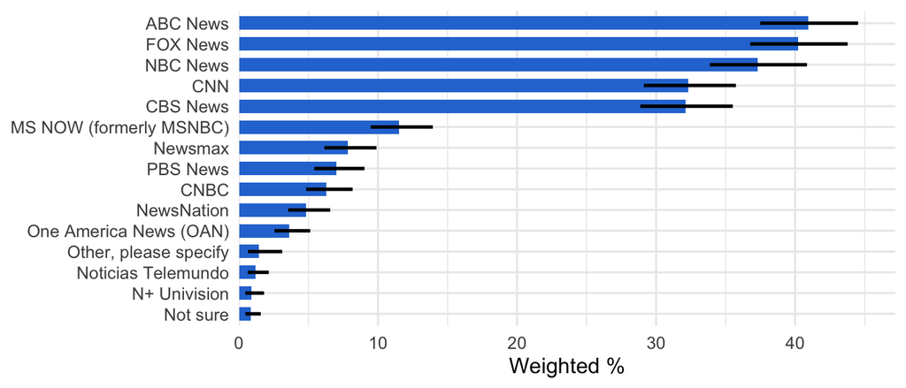

n = 1,109 — Base: BPC2_2 = 1 (national television)

### Radio programming

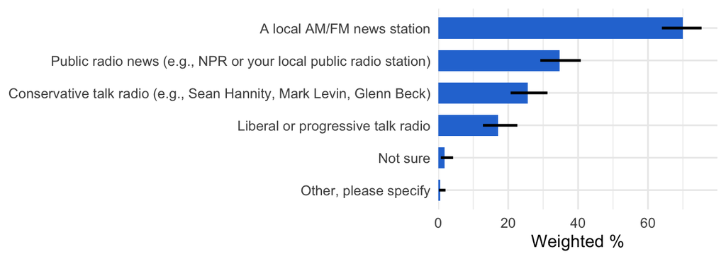

n = 375 — Base: BPC2_3 = 1 (radio)

### Print and online news outlets

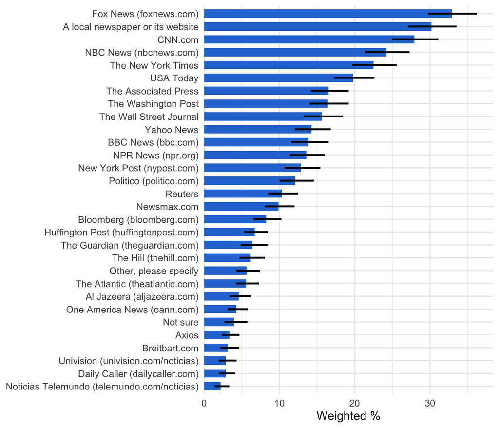

n = 1,146 — Base: BPC2_4 = 1 or BPC2_5 = 1 (print/online outlets)

### Social media platforms

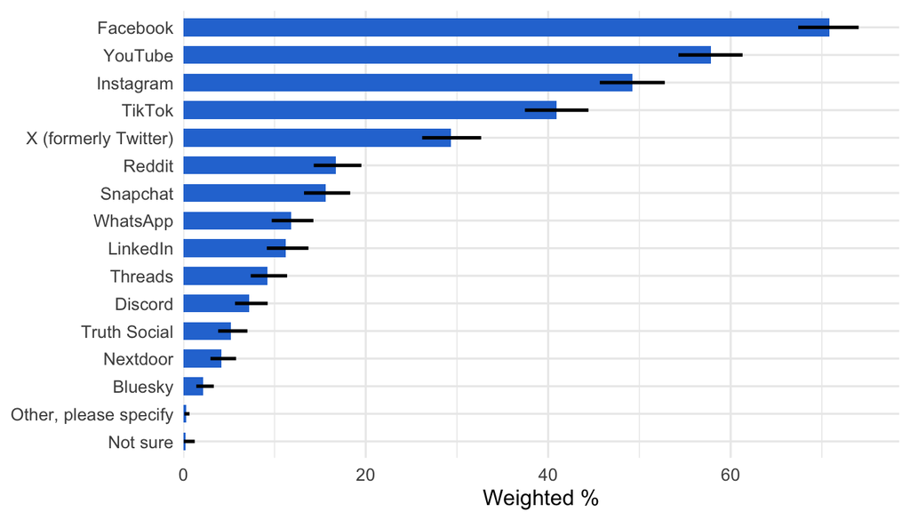

n = 1,147 — Base: BPC2_6 = 1 (social media)

### AI chatbots

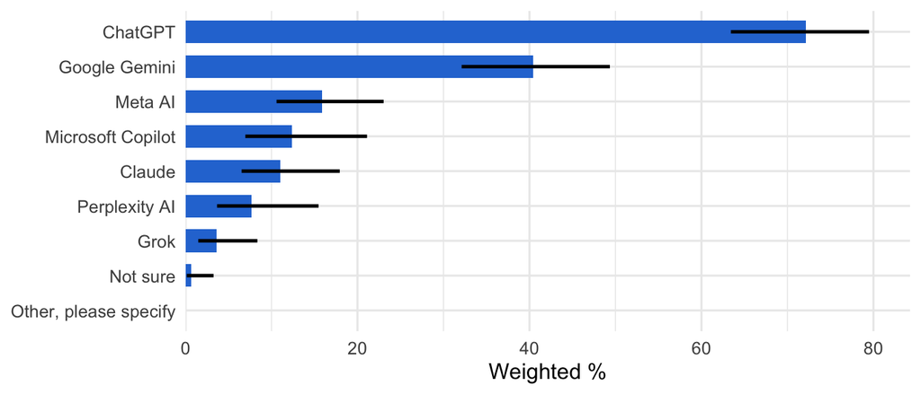

n = 173 — Base: BPC2_11 = 1 (AI chatbot). NOTE: the delivered stem says ‘select all that apply’ but the questionnaire specifies SELECT UP TO 2, and the data confirms the cap of 2 was programmed

# Part 2: Where Voters Look for Specific Kinds of Information

## Registering and Voting

### Which sources

#### Exclude never-seekers

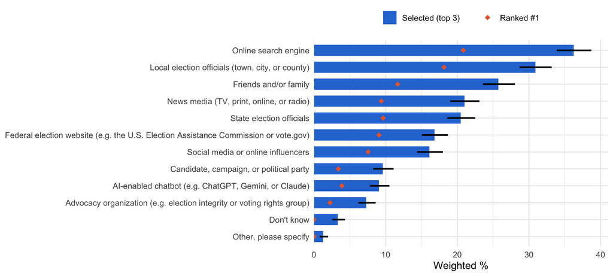

n = 2,349

**By party ID — selected**

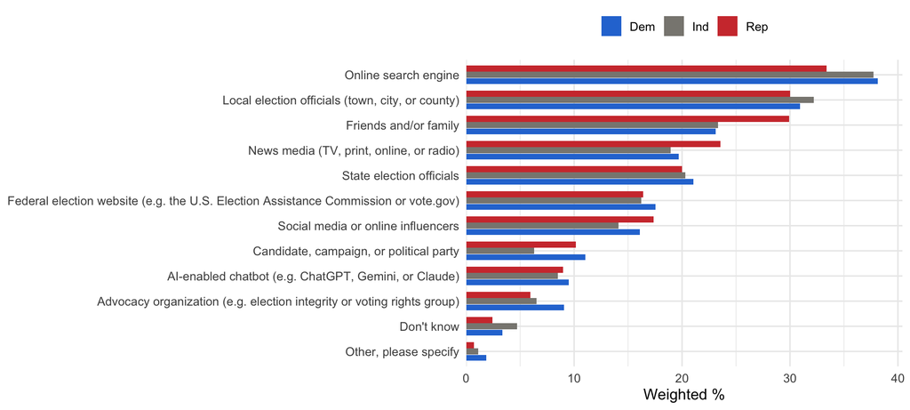

**By party ID — ranked #1**

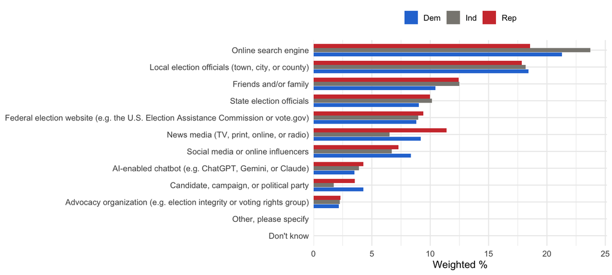

#### Include everyone

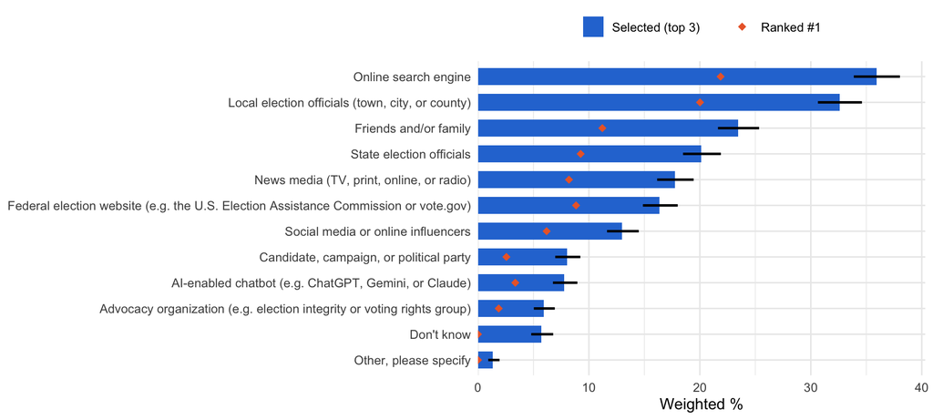

n = 3,144

**By party ID — selected**

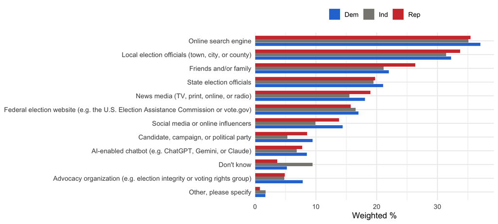

**By party ID — ranked #1**

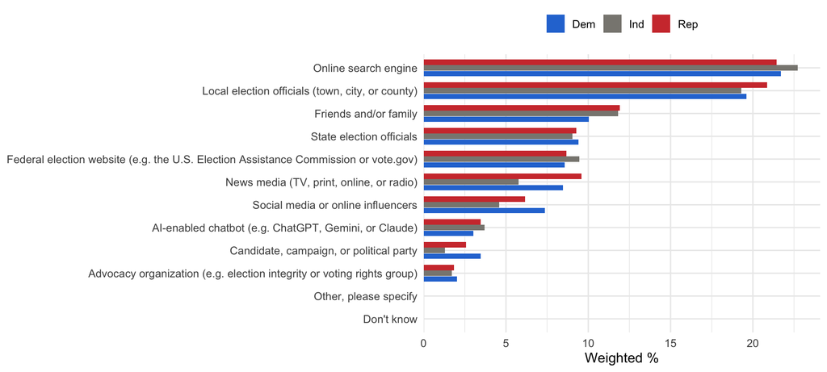

#### Never-seekers only

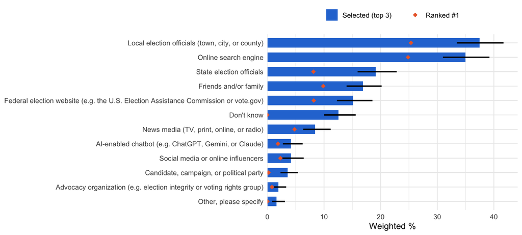

n = 795

**By party ID — selected**

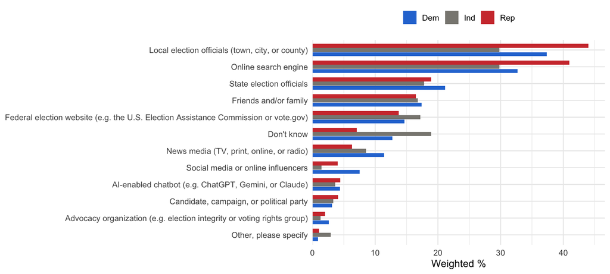

**By party ID — ranked #1**

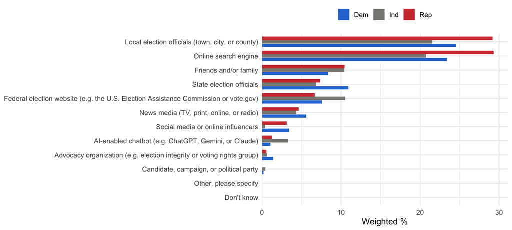

### Drill-downs (everyone included)

#### Contact mode (local/state election officials)

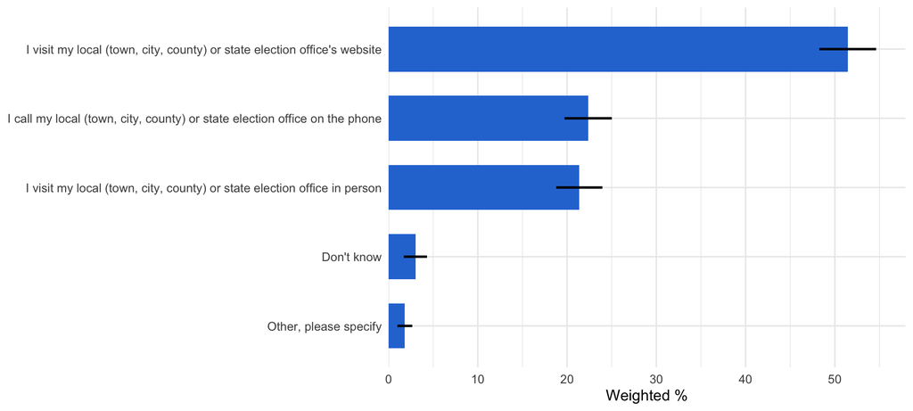

n = 1,373

**By party ID**

[figure not shown]

#### Social media platform

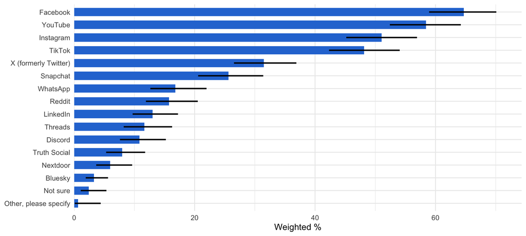

n = 435

**By party ID**

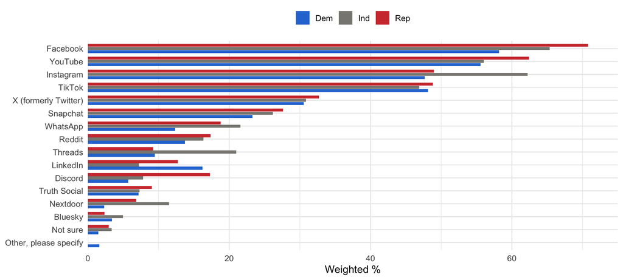

#### AI chatbot

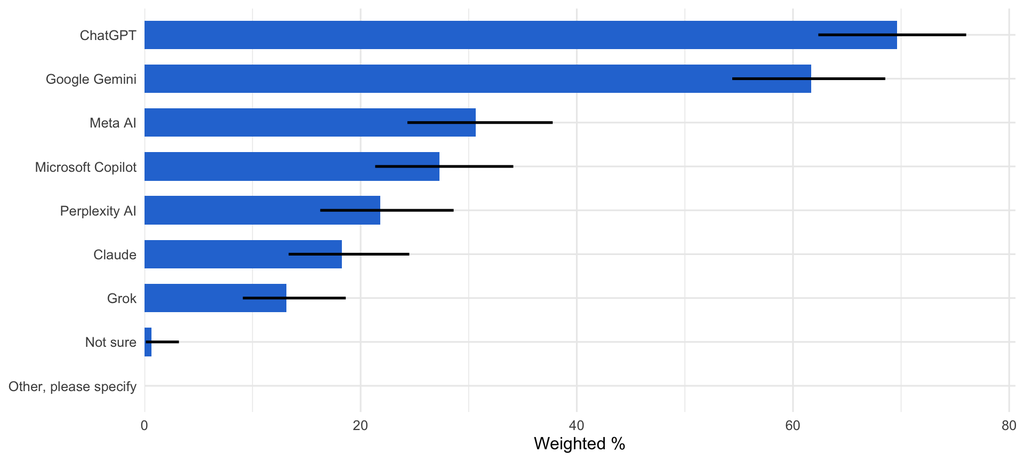

n = 251

**By party ID**

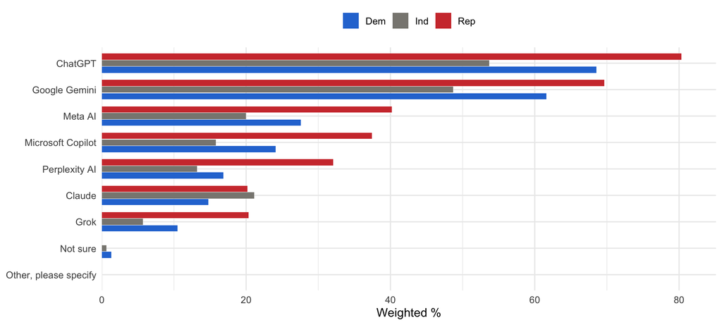

## How Elections Are Run

### Which sources

#### Exclude never-seekers

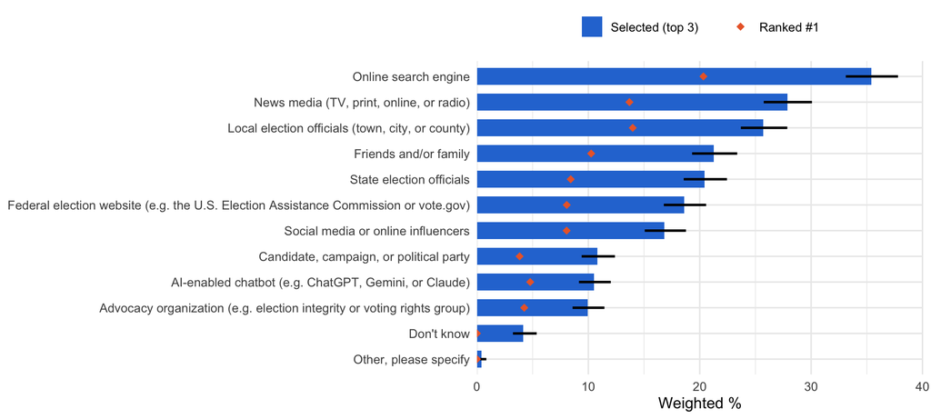

n = 2,401

**By party ID — selected**

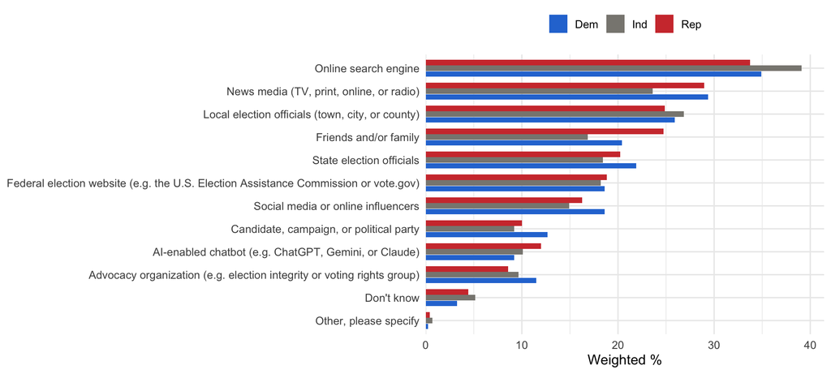

**By party ID — ranked #1**

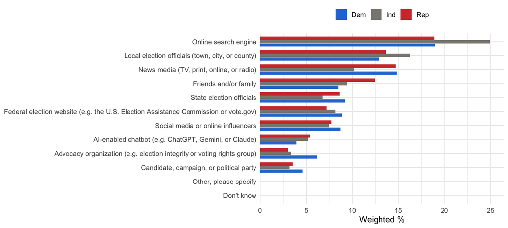

#### Include everyone

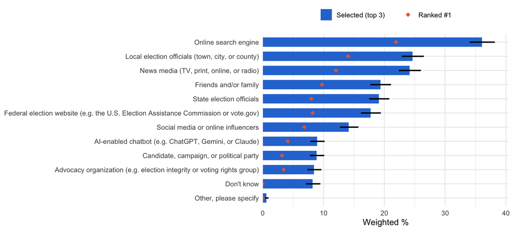

n = 3,144

**By party ID — selected**

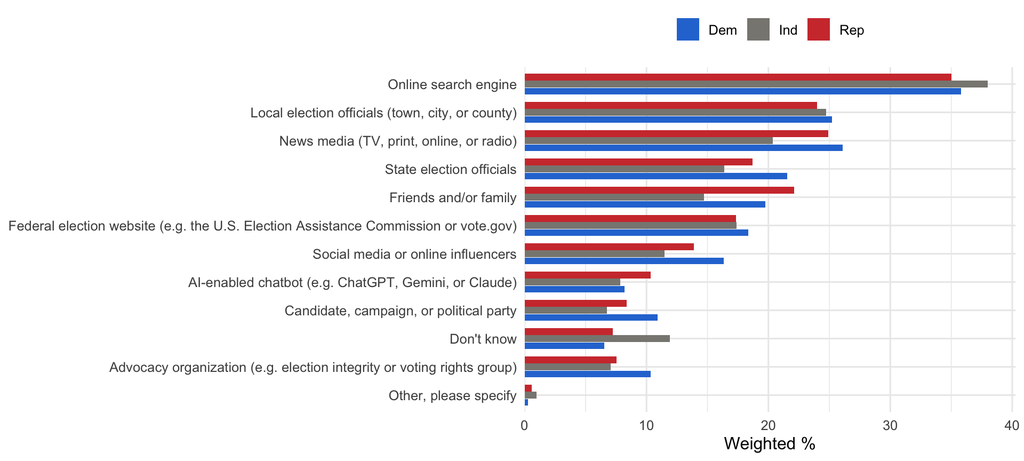

**By party ID — ranked #1**

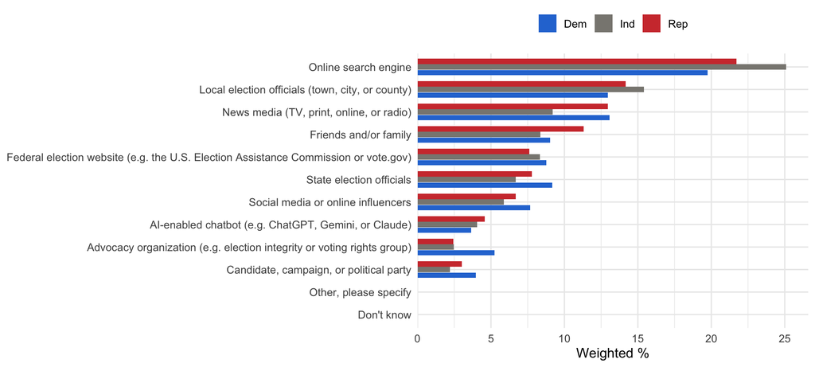